# Statistical Inference II

Author

Sepehr Akbari

Published

November 8, 2024

These problems refer to the `pokemon_sample` data set, available on Moodle, which represents a simple random sample of cards from the Pokemon trading card game. All questions refer to the population of all Pokemon that were ever released in generations 1-6. Adhere to all best-practices covered in class.

## Setup

```r
library(tidyverse)
library(readxl)
library(gt)

pokemon <- read_excel("../Data/pokemon_sample.xlsx")
```

## Problem 1

Do Pokemon from different generations have the same attack rating, on average?

To begin, let’s explore the structure of the data and familiarize ourselves with its contents.

```r
glimpse(pokemon)
```

```
Rows: 100
Columns: 12
$ Name       <chr> "Tirtouga", "Misdreavus", "LatiasMega Latias", "Amoonguss",…
$ `Type 1`   <chr> "Water", "Ghost", "Dragon", "Grass", "Psychic", "Grass", "S…
$ `Type 2`   <chr> "Rock", "NA", "Psychic", "Poison", "Fighting", "NA", "Fairy…
$ Total      <dbl> 355, 435, 700, 464, 618, 498, 380, 329, 680, 500, 670, 380,…
$ HP         <dbl> 54, 60, 80, 114, 68, 75, 50, 50, 150, 60, 100, 55, 35, 60, …
$ Attack     <dbl> 78, 60, 100, 85, 165, 98, 85, 50, 100, 65, 150, 63, 70, 85,…
$ Defense    <dbl> 103, 60, 120, 70, 95, 63, 85, 62, 120, 60, 140, 90, 55, 60,…
$ `Sp. Atk`  <dbl> 53, 85, 140, 85, 65, 98, 55, 40, 100, 130, 100, 50, 45, 50,…
$ `Sp. Def`  <dbl> 45, 85, 150, 80, 115, 63, 55, 62, 120, 75, 90, 80, 55, 50, …
$ Speed      <dbl> 22, 85, 110, 30, 110, 101, 50, 65, 90, 110, 90, 42, 25, 125…
$ Generation <chr> "Fifth", "Second", "Third", "Fifth", "Fourth", "Fifth", "Th…
$ Legendary  <lgl> FALSE, FALSE, TRUE, FALSE, FALSE, FALSE, FALSE, FALSE, TRUE…
```

Now that we know what we are working with, let’s lay our hypothesis:

Null Hypothesis ($H_0$): The mean attack rating of Pokemon is the same across generations.

Alternative Hypothesis ($H_1$): The mean attack rating of Pokemon differs by generation.

To get a sense of the average attack rating across generations, let’s calculate the mean attack rating for each generation.

```r
pokemon %>%
  group_by(Generation) %>%
  summarise(mean_attack = mean(Attack))
```

```
# A tibble: 6 × 2
  Generation mean_attack
  <chr>            <dbl>
1 Fifth             92.0
2 First             77.8
3 Fourth            98.9
4 Second            68.5
5 Sixth             73.4
6 Third             84.2
```

The initial summary suggests some variation in mean attack ratings between generations. To gain further insight into the distribution and potential impact of outliers, lets do a visualization.

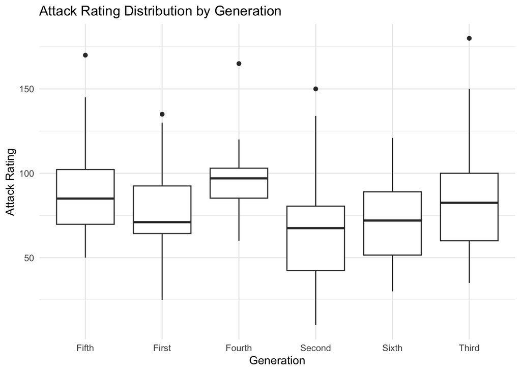

```r
ggplot(
  pokemon,
  aes(x = Generation,
      y = Attack)
  ) +
  geom_boxplot() +
  labs(
    title = "Attack Rating Distribution by Generation",
    x = "Generation",
    y = "Attack Rating"
  ) +
  theme_minimal()
```

The boxplot indicates noticeable differences in the distributions across generations, with some variability and outliers. However, it’s still unclear whether these differences are statistically significant or simply due to sampling. To formally test this, we’ll conduct an ANOVA test.

```r
anova_result <- aov(Attack ~ Generation, data = pokemon)
summary(anova_result)
```

```
            Df Sum Sq Mean Sq F value Pr(>F)
Generation   5   8676    1735   1.619  0.163
Residuals   94 100759    1072
```

The p-value for the effect of generation on attack rating is 0.163, which is above the common significance level of 0.05. Therefore, we fail to reject the null hypothesis. This suggests that there is no statistically significant difference in the average attack rating across Pokémon generations in this sample. While some variation exists in the data, it does not appear to be strong enough to conclude that different generations have distinct average attack ratings.

## Problem 2

Is it plausible that the same number of Pokemon have been released in every generation?

Let’s start by laying the hypothesis:

Null Hypothesis ($H_0$): The number of Pokemon released is the same for each generation.

Alternative Hypothesis ($H_1$): The number of Pokemon released is not the same for each generation.

To begin investigating, let’s examine the number of Pokemon released in each generation by getting a summary table.

```r
pokemon_counts <- pokemon %>%
  group_by(Generation) %>%
  summarise(Count = n()) %>%
  arrange(-Count)

gt::gt(pokemon_counts)
```

| Generation | Count |
| --- | --- |
| Third | 26 |
| Fifth | 20 |
| First | 18 |
| Second | 14 |
| Sixth | 12 |
| Fourth | 10 |

The table displays the counts of Pokemon released by generation, indicating variability across different generations. To further explore, we can visualize this data with a bar chart.

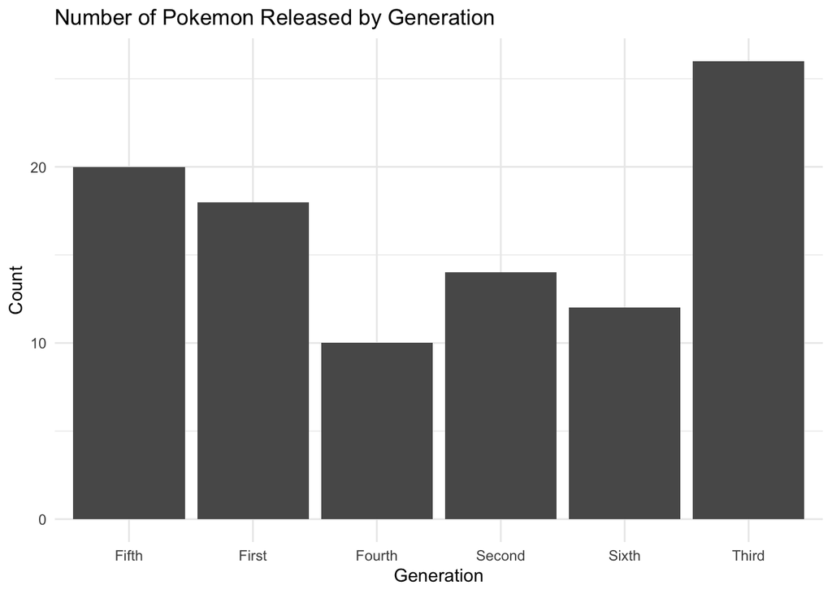

```r
ggplot(
  pokemon_counts,
  aes(x = Generation,
      y = Count)
) +
  geom_bar(stat = "identity") +
  labs(
    title = "Number of Pokemon Released by Generation",
    x = "Generation",
    y = "Count"
  ) +
  theme_minimal()
```

The bar chart reveals noticeable variation in the number of Pokemon released across generations, with some generations having more releases than others. However, we need a formal test to determine if these differences are statistically significant.

```r
chisq.test(pokemon_counts$Count, p = rep(1/6, 6))
```

```
    Chi-squared test for given probabilities

data:  pokemon_counts$Count
X-squared = 10.4, df = 5, p-value = 0.06466
```

With a p-value of 0.06466, which is just above the standard significance level of 0.05, we do not have sufficient evidence to reject the null hypothesis. This suggests that the variation in the number of Pokemon released across generations could plausibly be due to random chance rather than a systematic difference. Therefore, it is statistically plausible that the same number of Pokemon could have been released in each generation, despite the observed differences.

## Problem 3

A friend tells you that the average attack rating of all Pokemon is 70. Does the data provide evidence against (or for) this claim?

Laying the hypothesis:

Null Hypothesis ($H_0$): The average attack rating of all Pokemon is 70.

Alternative Hypothesis ($H_1$): The average attack rating of all Pokemon is not 70.

Let’s begin by calculating the sample mean of the attack ratings.

```r
mean(pokemon$Attack)
```

```
[1] 82.58
```

No let’s get a visualization to see where the mean of the attack ratings in this sample falls relative to our null hypothesis, 70.

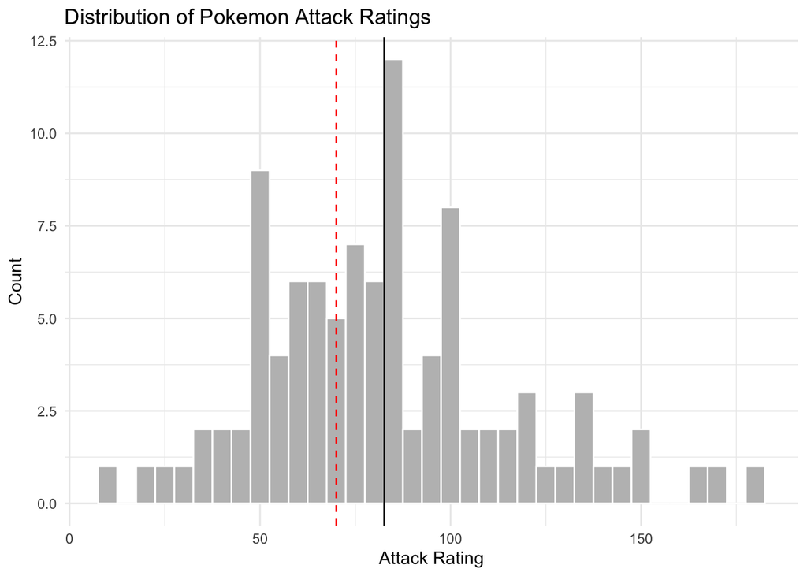

```r
ggplot(
  pokemon,
  aes(x = Attack)
) +
  geom_histogram(
    binwidth = 5,
    fill = "gray",
    color = "white"
  ) +
  geom_vline(
    aes(xintercept = 70),
    color = "Red",
    linetype = "dashed"
  ) +
  geom_vline(
    aes(xintercept = mean(Attack)),
    color = "Black"
  ) +
  labs(
    title = "Distribution of Pokemon Attack Ratings",
    x = "Attack Rating",
    y = "Count"
  ) +
  theme_minimal()
```

The distribution of attack ratings shows that the sample mean is above 70, but it is essential to determine if this difference is statistically significant. To do this, we can conduct a t-test.

```r
t.test(pokemon$Attack,
       mu = 70)
```

```
    One Sample t-test

data:  pokemon$Attack
t = 3.7837, df = 99, p-value = 0.0002647
alternative hypothesis: true mean is not equal to 70
95 percent confidence interval:
 75.98297 89.17703
sample estimates:
mean of x
    82.58
```

With a p-value of 0.0002647, which is well below the common significance level of 0.05, we reject the null hypothesis. This indicates that there is strong statistical evidence to conclude that the average attack rating of all Pokemon is significantly different from 70. So, the data does not support the friend’s claim!

## Problem 4

Recreate the table below and then create an attractive visualization showing showing attack rating vs type for the five most common types of Pokemon. Note that Type is split between two columns and you must consider both equally.

Modifying the data to include a Type column with the top 5 appeared selected:

```r
ranking_types <- pokemon %>%
  pivot_longer(
    cols = c(`Type 1`, `Type 2`),
    values_to = "Type"
  ) %>%
  filter(Type != "NA") %>%
  group_by(Type) %>%
  summarize(
    Count = n(),
    mean_attack = mean(Attack),
    mean_defense = mean(Defense)
  ) %>%
  arrange(-Count)

top_types <- ranking_types %>%
  slice_max(Count, n = 5)
```

Displaying the table:

```r
top_types %>%
  gt() %>%
  cols_label(
    Type = "Type",
    Count = "Count",
    mean_attack = "Avg attack",
    mean_defense = "Avg defense"
  ) %>%
  fmt_number( # formatting for the decimals
    columns = c(mean_attack, mean_defense),
    decimals = 1
  )
```

| Type | Count | Avg attack | Avg defense |
| --- | --- | --- | --- |
| Water | 16 | 78.8 | 82.4 |
| Psychic | 14 | 73.3 | 79.8 |
| Grass | 12 | 71.8 | 65.8 |
| Normal | 12 | 68.8 | 60.4 |
| Dragon | 11 | 95.1 | 87.5 |

Visualization showing attack rating and defense rating:

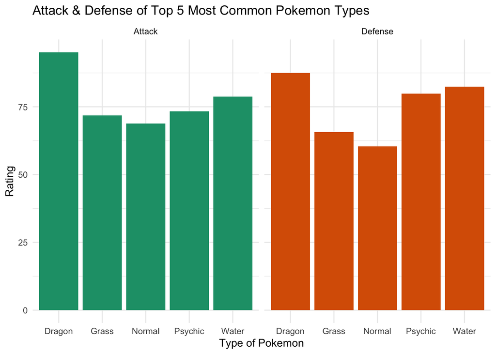

```r
top_types_long <- top_types %>%
  pivot_longer(
    cols = c(mean_attack, mean_defense),
    names_to = "Stat",
    values_to = "Value"
  ) %>%
  mutate(
    Stat = ifelse(Stat == "mean_attack", "Attack", "Defense")
  )

ggplot(
  top_types_long,
  aes(x = Type,
      y = Value,
      fill = Stat)
) +
  geom_col(position = "dodge", show.legend = FALSE) +
  facet_wrap(~Stat) +
  labs(
    title = "Attack & Defense of Top 5 Most Common Pokemon Types",
    x = "Type of Pokemon",
    y = "Rating"
  ) +
  scale_fill_brewer(palette = "Dark2") +
  theme_minimal()
```

## Problem 5

Is it plausible that the top 5 most common types of Pokemon all have the same defense rating, on average?

Let’s lay the hypothesis:

Null Hypothesis ($H_0$): The average defense rating is the same across the top 5 most common Pokemon types.

Alternative Hypothesis ($H_1$): The average defense rating is different for at least one of the top 5 types.

For this, we cannot use the `top_types` data frame as it only contains the mean defense rating for each type. We need to use the original data to conduct an ANOVA test. So let’s create a new data frame that has a single column for Type, and filter the set to only include the top 5 types.

```r
top_types_data <- pokemon %>%
  pivot_longer(
    cols = c(`Type 1`, `Type 2`),
    values_to = "Type"
  ) %>%
  filter(Type %in% top_types$Type)
```

Now that we have the dataset that we needed, let’s get a visualization to see how the defense ratings are distributed across the top 5 types.

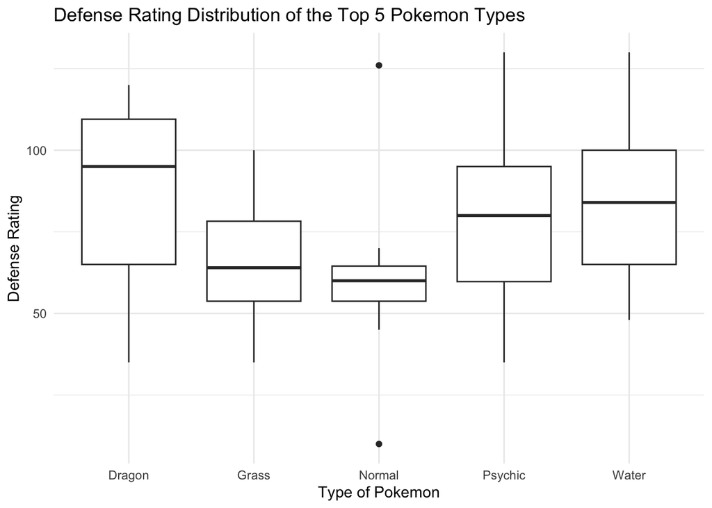

```r
ggplot(
  top_types_data,
  aes(x = Type,
      y = Defense)
) +
  geom_boxplot() +
  labs(
    title = "Defense Rating Distribution of the Top 5 Pokemon Types",
    x = "Type of Pokemon",
    y = "Defense Rating"
  ) +
  theme_minimal()
```

In first glance, it definetly seems like there are some differences in the average defense ratings across the top 5 types. To formally test this, we can conduct an ANOVA test.

```r
anova_result <- aov(Defense ~ Type, data = top_types_data)
summary(anova_result)
```

```
            Df Sum Sq Mean Sq F value Pr(>F)
Type         4   6470  1617.4   2.631 0.0429 *
Residuals   60  36882   614.7
---
Signif. codes:  0 '***' 0.001 '**' 0.01 '*' 0.05 '.' 0.1 ' ' 1
```

The p-value is 0.0429 which is below the common significance level of 0.05. Therefore, we reject the null hypothesis and conclude that the average defense rating is different across the top 5 most common Pokemon types. This suggests that there are statistically significant differences in defense ratings among these types, indicating that they do not all have the same defense rating, on average.